# Sparse Sim

```r
library('mash')
chat_sim_fsimple
```

```
## function(n=1000,d=8,betasd=1,esd=0.1,K=10){
##   library("MASS")
##   library("mvtnorm")
##   J=0.10*n
##   temp=rep(list(c(0,1)),d)
##   configs = expand.grid(temp) # all possible 2^d combinations
##   S=sample(seq(1:nrow(configs)),size = K,replace = FALSE)##which factors will be used
##   F=as.matrix(configs[S,])
##   covmat=lapply(seq(1:K),function(k){
##     A=F[k,]%*%t(F[k,]);
##     A/max(diag(A))})
##   ## each entry of F is the the factor of decomposition of covariance of effect sizes
##   z = sample(K,J,replace=TRUE) # randomly sample factor to be loaded on for each real snp
##
##
##   mus=rnorm(n)  ###generate a list of n mus
##   mumat=matrix(rep(mus,d),ncol=d)##generate a matrix of mus for each gene
##   omega=abs(rnorm(J,mean=0,sd=betasd))##effect size variance can be big or small
##   beta=t(sapply(seq(1:J),function(j){
##     k=z[j]
##     mvrnorm(1,mu=rep(0,d),Sigma=omega[j]*covmat[[k]])
##     #rmvnorm(1,mean = rep(0,d),sigma=omega*covmat[[k]])
##   }))
##
##   beta=rbind(beta,matrix(rep(0,(n-J)*d),ncol=d))
##   c=beta+mumat
##   sj=abs(matrix(rnorm(n*d,esd,0.001),ncol=d))##use uniform to simulate 'shrunken'
##   e=t(apply(sj,1,function(x){rmvnorm(1,mean=rep(0,d),sigma=diag(x)^2)}))
##   chat=c+e
##   t=chat/sj
##   return(list(beta=beta,chat=chat,covmat=covmat,components=z,factors=F,t=t,mumat=mumat,shat=sj,error=e,ceff=c,omega=omega))
## }
## <environment: namespace:mash>
```

You can see that the covariance matrices correspond to the factors:

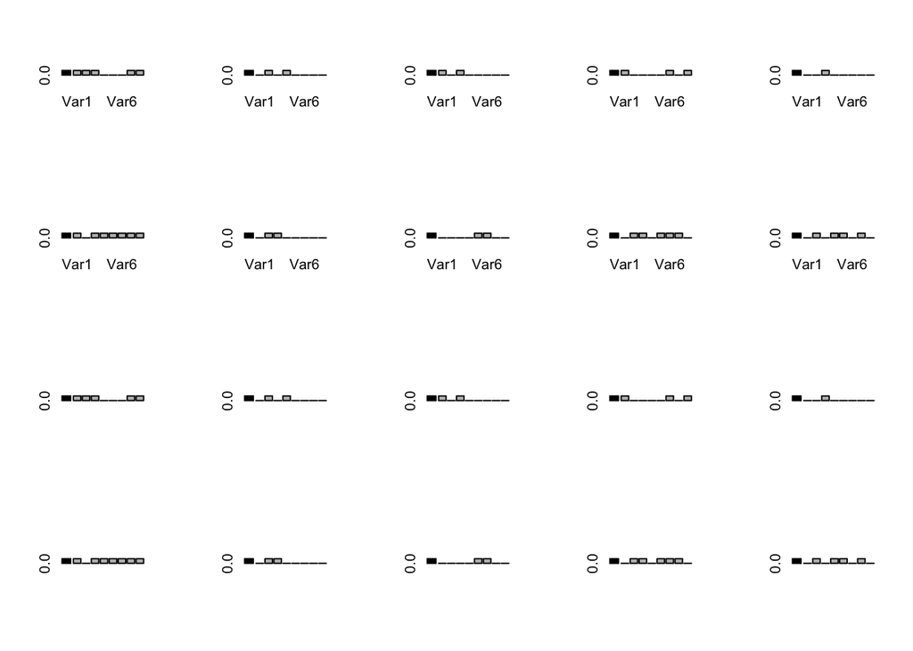

```r
rm(list=ls())

set.seed(123)
RNGkind("Mersenne-Twister")
c=chat_sim_fsimple(n=10000,d=8,betasd=1,esd=0.1,K=10)


par(mfrow=c(4,5))
for(i in 1:nrow(c$factors)){
  x=c$factors[i,]
  barplot(x)}
for(i in 1:length(c$covmat)){
  x=c$covmat[[i]]
    barplot(rowSums(x)!=0)
  }
```

```r
identical(c$beta[1,]+c$mumat[1,],c$ceff[1,])
```

```
## [1] TRUE
```

```r
identical(c$chat[1,],c$ceff[1,]+c$error[1,])
```

```
## [1] TRUE
```

Furthermore, you can see that the components look like such:

```r
t(sapply(c$covmat,function(x){diag(x)}))
```

```
##       [,1] [,2] [,3] [,4] [,5] [,6] [,7] [,8]
##  [1,]    1    1    1    0    0    0    1    1
##  [2,]    0    1    0    1    0    0    0    0
##  [3,]    1    0    1    0    0    0    0    0
##  [4,]    1    0    0    0    0    1    0    1
##  [5,]    0    0    1    0    0    0    0    0
##  [6,]    1    0    1    1    1    1    1    1
##  [7,]    0    1    1    0    0    0    0    0
##  [8,]    0    0    0    0    1    1    0    0
##  [9,]    0    1    1    0    1    1    1    0
## [10,]    0    1    0    1    1    0    1    0
```

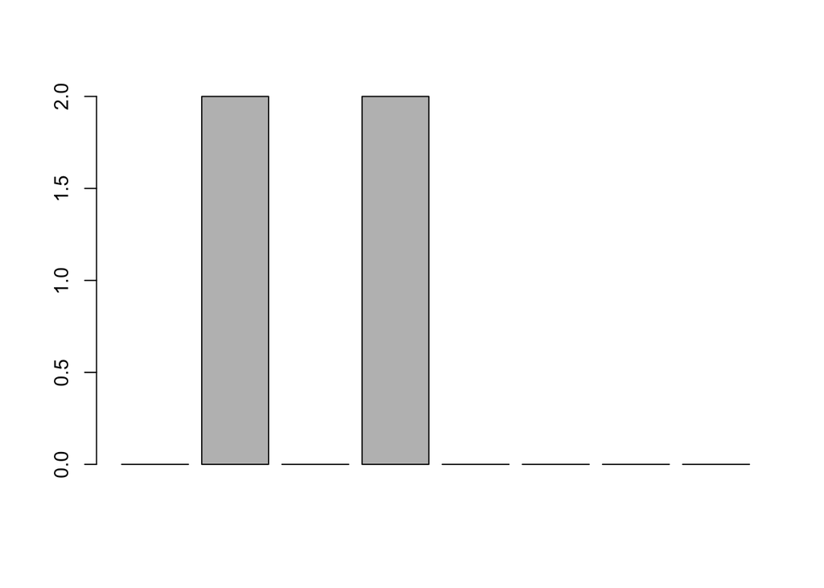

```r
barplot(rowSums(c$covmat[[2]]))
```

```r
comptwoers=which(c$components==2)[1:5]

c$beta[comptwoers,]
```

```
##      [,1]       [,2] [,3]       [,4] [,5] [,6] [,7] [,8]
## [1,]    0 -0.1047601    0 -0.1047601    0    0    0    0
## [2,]    0 -1.6506007    0 -1.6506008    0    0    0    0
## [3,]    0  0.1821827    0  0.1821827    0    0    0    0
## [4,]    0  2.5297006    0  2.5297006    0    0    0    0
## [5,]    0  0.3414619    0  0.3414620    0    0    0    0
```

```r
(c$beta[comptwoers,])
```

```
##      [,1]       [,2] [,3]       [,4] [,5] [,6] [,7] [,8]
## [1,]    0 -0.1047601    0 -0.1047601    0    0    0    0
## [2,]    0 -1.6506007    0 -1.6506008    0    0    0    0
## [3,]    0  0.1821827    0  0.1821827    0    0    0    0
## [4,]    0  2.5297006    0  2.5297006    0    0    0    0
## [5,]    0  0.3414619    0  0.3414620    0    0    0    0
```

Now, let’s do our analysis:

```r
saveRDS(c,"chatsimesparsef.rds")
t=c$t;b=c$chat;se=c$shat
#hist(t)
#hist(b)
R=ncol(t)
L=diag(R)-1/R*as.vector(rep(1,R))%*%t(as.vector(rep(1,R)))
s.j=se/se

absmat=abs(t(L%*%t(c$t)))
index=which(rowSums(absmat>4)>0)
length(index)
```

```
## [1] 507
```

```r
mean(index<1000)
```

```
## [1] 0.9940828
```

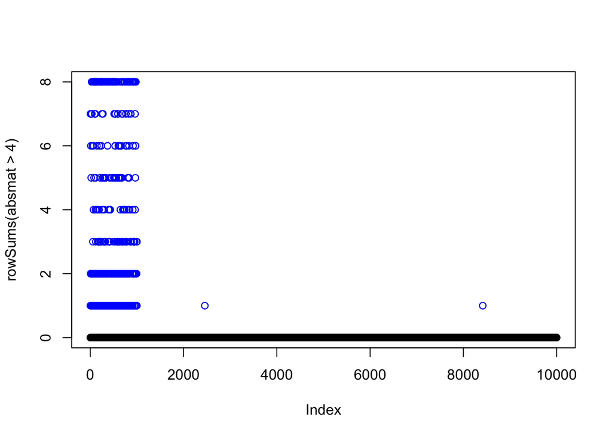

```r
#index=which(rowMeans(abs(t(L%*%t(c$t))))>1.3)##choose the associations with average deviation large.

##show deviations
plot(rowSums(absmat>4))
points(index,rowSums(absmat>4)[index],col="blue")
```

```r
sparsestrongt=t(L%*%t(t[index,]))
```

```r
write.table(sparsestrongt,"sparsestrongt.txt",col.names = FALSE,row.names=FALSE)
```

Now, we need to project into the centered space to estimate the covariance matrix of the true deviations, using the full L since $v$ will be R, and not $R-1$.

```r
system('/Users/sarahurbut/miniconda3/bin/sfa -gen sparsestrongt.txt -g 507 -k 5 -n 8 i -o sparseF')
A="sparseF"

factor.mat=as.matrix(read.table("sparseF_F.out"))
lambda.mat=as.matrix(read.table("sparseF_lambda.out"))

#recall here that w will now be the L[-1,]%*%t(t[strong,]), which is equivalent to removing the first column of the strong projected t. Thus the covariance of v is initated with the RxR matrices (strong projected t), and the model is trained on the strong projected t less the first column because the model has v_{rxr}|w_{r,r-1}

strongprojectedt=sparsestrongt


lvllist=genlvllist(s.j[index,],L = L[-1,])


##w should represent transformed betahats using all R subgroups and j genes
wfull=t(L%*%t(b))
sjmat=convertstandarderrors(s.j = se,L=L)##make this be the standard errors of all, it is the sqrt of the diagonal of LVL' for each j. Recall here L is still RxR so we can have the full set of deviations and thier standard errors to choose grid
dim(wfull)
```

```
## [1] 10000     8
```

```r
dim(sjmat)
```

```
## [1] 10000     8
```

Compute the likelihood without ED:

```r
A="noedcovsparse"
noedcov=compute.covmat(b.gp.hat = wfull,sebetahat = sjmat,Q = 5,t.stat = strongprojectedt,lambda.mat = lambda.mat,P = 3,A = "noedcovsparse",factor.mat = factor.mat,bma = T,zero = T,power = 2)$cov
```

Check that all the matrices are correctly computed:

```r
pca=svd(strongprojectedt);v=pca$v[,1:3];d=pca$d[1:3];u=pca$u[,1:3]
pcaprox=t(u%*%diag(d)%*%t(v))%*%(u%*%diag(d)%*%t(v))/max(diag(t(u%*%diag(d)%*%t(v))%*%(u%*%diag(d)%*%t(v))))


P=3;X.c=apply(strongprojectedt,2,function(x) x-mean(x)) ##Column centered matrix of t statistics
svd.X=svd(X.c)
M=nrow(X.c)
v=svd.X$v;u=svd.X$u;d=svd.X$d
cov.pc=1/M*v[,1:P]%*%diag(d[1:P])%*%t(u[,1:P])%*%t(v[,1:P]%*%diag(d[1:P])%*%t(u[,1:P]))

for(q in 1:5){
load=as.matrix(lambda.mat[,q])
fact=as.matrix(factor.mat[q,])
rank.prox=load%*%t(fact)
a=(1/(M-1)*(t(rank.prox)%*% rank.prox))/max(diag((1/(M-1)*(t(rank.prox)%*% rank.prox))))
print(all.equal(as.numeric(a),as.numeric(noedcov[[3+q]]/max(diag(noedcov[[3+q]])))))}

load=as.matrix(lambda.mat)
fact=as.matrix(factor.mat)
rank.prox=load%*%(fact)
a=(1/(M-1)*(t(rank.prox)%*% rank.prox))/max(diag((1/(M-1)*(t(rank.prox)%*% rank.prox))))
all.equal(as.numeric(a),as.numeric(noedcov[[9]]/max(diag(noedcov[[9]]))))

all.equal(cov(strongprojectedt)/max(diag(cov(strongprojectedt))),noedcov[[2]]/max(diag(noedcov[[2]])))
all.equal(as.numeric(cov.pc)/max(diag(cov.pc)),as.numeric(noedcov[[3]]/max(diag(noedcov[[3]]))))
```

[output not shown]

$Likelihood$

Now we will replace the RxR matrix $L$ with the $R-1xR$ matrix $L∗$, effectively removing a data point from the observed uncentered statistics, such that the rank of the marginal variance of $w$ is guaranteed to be equal to the dimension of $w$.

Now we will replace the RxR matrix $L$ with the R-1xR matrix $L*$, effectively removing a data point from the observed uncentered statistics, such that the rank of the marginal variance of $w$ is guaranteed to be equal to the dimension of $w$.

Now for each gene J at each component k, integrating over $\beta$,

$L_{R-1,R} ceff \sim N (0, L_{R-1,R} U_{k} L_{R-1,R} ')$ $L_{R-1,R} chat \sim N (0, L_{R-1,R} U_{k} L_{R-1,R} ' + L_{R-1,R} \hat{V} L_{R-1,R} ')$

And thus we can use the Bovy et al algorithm invoked in both the Extreme Deconvolution package and in `Sarah’s MixEm’ where the marginal variance at each component, $T_{jp}$:

$T_{jp} = L_{R-1,R} U_k L_{R-1,R}' + L_{R-1,R} \hat{V}_{j} L_{R-1,R}'$

For each gene, and $w_{j} = L_{R-1,R} chat_{j}$.

Recall that our previous approach was simplified by the fact that ${w}_{j}$ was simply $\hat{{b}_{j}}$ and the projection matrix was simply the $I_{r}$ identity matrix. Our inference on ${b}$ was analogous to their inference on $\beta_{j}$.

As before, we are interested in returning the prior covariance $U_k$ matrices of the `true` deviations $\beta$, which we will then rescale by choosing a set of $\omega$ that are appropriate to $L chat $ to comprise a set of $P = KxL$ prior covariance matrices $\Sigma$.

and choose the set of $\pi$ that maximizes compute the following likelihood at each of the P components:

$L_{R-1,R} chat _j \sim N (0, L_{R-1,R} \Sigma_{p} L_{R-1,R} ' + L_{R-1,R} \hat{V_j} L_{R-1,R} ')$

Now compute likelihood without ED:

```r
w=data.frame(wfull)[,-1]

A="noedcovsparse"
compute.hm.train.log.lik.pen.with.L(w,se.train = se,covmat = noedcov,A,pen = 1,L = L[-1,])
```

```r
pis=readRDS(paste0("pis",A,".rds"))$pihat

likmat=readRDS(paste0("liketrain",A,".rds"))
test=exp(likmat)
sum(log(test%*%pis))
```

```
## [1] 64212.25
```

Now run with ED to show that 1) the likelihood improves 2) we have successfully implemented an approach which allows us to input a list of residual variance matrices (as opposed to a matrix of vectors to be diagonalised).

```r
rm(A)
rm(noedcov)

library("ExtremeDeconvolution")
efunc=deconvolution.em.with.bovy.with.L(t.stat = strongprojectedt,factor.mat = factor.mat,lambda.mat = lambda.mat,v.j = lvllist,P = 3,L = L[-1,],Q = 5,w = strongprojectedt[,-1])

A="sparseL"


apply(efunc$true.covs,1,function(x){qr(x)$rank})
```

```
## [1] 7 5 3 1 1 1 1 1
```

```r
max.step=efunc
edcov=compute.hm.covmat.all.max.step(b.hat = wfull,se.hat = sjmat,t.stat = strongprojectedt,Q = 5,lambda.mat = lambda.mat,A=A,factor.mat = factor.mat,max.step = efunc,zero = T,power = 2)$cov
length(edcov)
```

```
## [1] 397
```

```r
all.equal(edcov[[2]]/max(diag(edcov[[2]])),max.step$true.covs[1,,]/max(diag(max.step$true.covs[1,,])))
```

```
## [1] TRUE
```

```r
all.equal(edcov[[3]]/max(diag(edcov[[3]])),max.step$true.covs[3,,]/max(diag(max.step$true.covs[3,,])))
```

```
## [1] TRUE
```

```r
all.equal(edcov[[9]]/max(diag(edcov[[9]])),max.step$true.covs[2,,]/max(diag(max.step$true.covs[2,,])))
```

```
## [1] TRUE
```

```r
A="sparseL"
w=data.frame(wfull)[,-1]

compute.hm.train.log.lik.pen.with.L(w,se.train = se,covmat = edcov,A = A,pen = 1,L = L[-1,])
```

```r
pis=readRDS(paste0("pis",A,".rds"))$pihat

likmat=readRDS(paste0("liketrain",A,".rds"))
test=exp(likmat)
sum(log(test%*%pis))
```

```
## [1] 64906.85
```

```r
for(j in 1:nrow(w)){
total.quant.per.snp.no.baseline(j = j,covmat = edcov,b.gp.hat = w,se.gp.hat = se,pis = pis,A = A,checkpoint = F,L = L[-1,])}
```

As you can see, the likelihood is much better with ED.

## Test to show our calculations are accurate:

### Compare with MASH

Now we can compare with mash. In this model, for each gene J:

$chat |\mu, V = \mu + \beta + E$

$chat - \mu = \beta + E$

and $E ~ N(0,V)$ while $\beta ~ \sum_{p} \pi_{p} N(0, U_{p})$

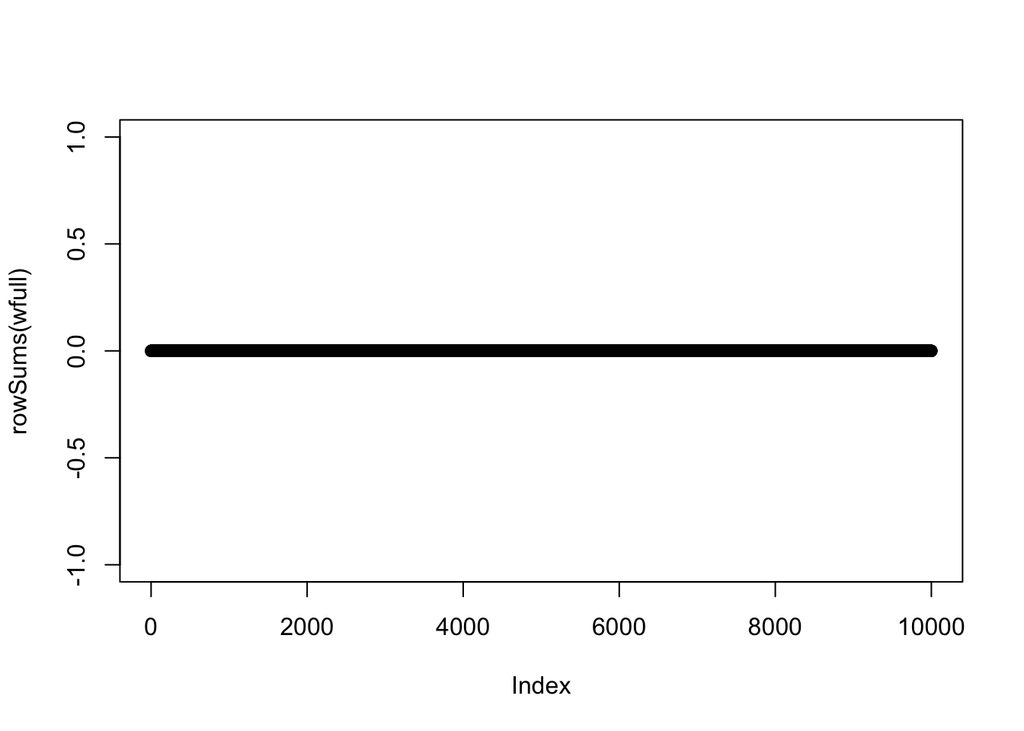

```r
rm(list=ls())
c=readRDS("chatsimesparsef.rds")

t=c$t;b=c$chat;se=c$shat;R=ncol(t)
L=diag(R)-1/R*as.vector(rep(1,R))%*%t(as.vector(rep(1,R)))
wfull=t(L%*%t(b))
##show that they sum to 0

plot(rowSums(wfull),ylim=c(-1,1))
```

Now we proceed as in mash, selecting the strong t statistics:

```r
s.j=se/se
absmat=abs(t(L%*%t(c$t)))


index=which(rowSums(absmat>4)>0)
length(index)
```

```
## [1] 507
```

```r
mean(index<1000)
```

```
## [1] 0.9940828
```

```r
factor.mat=as.matrix(read.table("sparseF_F.out"))
lambda.mat=as.matrix(read.table("sparseF_lambda.out"))



strongprojectedtsimulations=t(L%*%t(t[index,]))
max.step=deconvolution.em.with.bovy(t.stat = strongprojectedtsimulations,factor.mat = factor.mat,v.j = s.j,lambda.mat = lambda.mat,K = 3,P = 3 )

##Show how the ranks is preserved
apply(max.step$true.covs,1,function(x){qr(x)$rank})
```

```
## [1] 7 5 3
```

```r
covmash=compute.hm.covmat.all.max.step(max.step = max.step,b.hat = wfull,se.hat = se,t.stat = strongprojectedtsimulations,Q = 5,lambda.mat = lambda.mat,A = "sparseoldmash",factor.mat = factor.mat,zero = T,power = 2)$covmat

all.equal(covmash[[2]]/max(diag(covmash[[2]])),max.step$true.covs[1,,]/max(diag(max.step$true.covs[1,,])))
```

```
## [1] TRUE
```

```r
all.equal(covmash[[3]]/max(diag(covmash[[3]])),max.step$true.covs[3,,]/max(diag(max.step$true.covs[3,,])))
```

```
## [1] TRUE
```

```r
all.equal(covmash[[9]]/max(diag(covmash[[9]])),max.step$true.covs[2,,]/max(diag(max.step$true.covs[2,,])))
```

```
## [1] TRUE
```

Now, proceed as always, estimating likelihood and computing posteriors.

```r
A="sparseoldmash"
compute.hm.train.log.lik.pen(train.b = wfull,se.train = se,covmat = covmash,A=A,pen=1)
```

```r
pis=readRDS(paste0("pis",A,".rds"))$pihat
b.test=t
se.test=s.j
weightedquants=lapply(seq(1:nrow(wfull)),function(j){total.quant.per.snp(j,covmash,b.gp.hat=wfull,se.gp.hat = se,pis,A=A,checkpoint = FALSE)})
```

### Identifiability comparisons

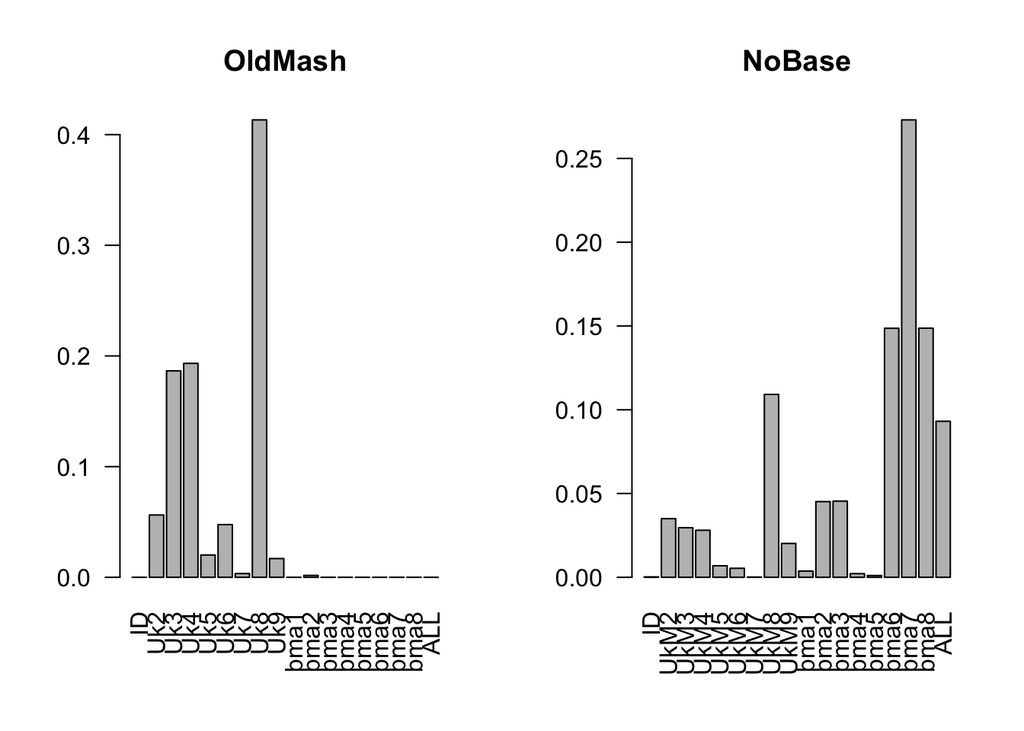

```r
pis=readRDS("pissparseoldmash.rds")$pihat
pi.mat.old.mash=matrix(pis[-length(pis)],ncol=18,byrow=TRUE)
pisnobase=readRDS("pissparseL.rds")$pihat
pi.mat.nobase=matrix(pisnobase[-length(pisnobase)],ncol=18,byrow=TRUE)
par(mfrow=c(1,2))
barplot(colSums(pi.mat.old.mash),main="OldMash",names=c("ID",rep(paste0("Uk",(2:9))),rep(paste0("bma",(1:8))),"ALL"),las=2)
barplot(colSums(pi.mat.nobase),main="NoBase",names=c("ID",rep(paste0("UkM",(2:9))),rep(paste0("bma",(1:8))),"ALL"),las=2)
```

It seems that *mashnobaseline* puts more weight on the ‘singleton configurations’.

Let’s look at the ‘learned’ covariance matrix of each as well as the true covariance matrices of each, and see how they comapre to the true configurations. Recall that the true configurations looked like this:

```r
c=readRDS("~/mashnobaseline/Simulations/sparsesim/chatsimesparsef.rds")
t(sapply(c$covmat,function(x){diag(x)}))
```

```
##       [,1] [,2] [,3] [,4] [,5] [,6] [,7] [,8]
##  [1,]    1    1    1    0    0    0    1    1
##  [2,]    0    1    0    1    0    0    0    0
##  [3,]    1    0    1    0    0    0    0    0
##  [4,]    1    0    0    0    0    1    0    1
##  [5,]    0    0    1    0    0    0    0    0
##  [6,]    1    0    1    1    1    1    1    1
##  [7,]    0    1    1    0    0    0    0    0
##  [8,]    0    0    0    0    1    1    0    0
##  [9,]    0    1    1    0    1    1    1    0
## [10,]    0    1    0    1    1    0    1    0
```

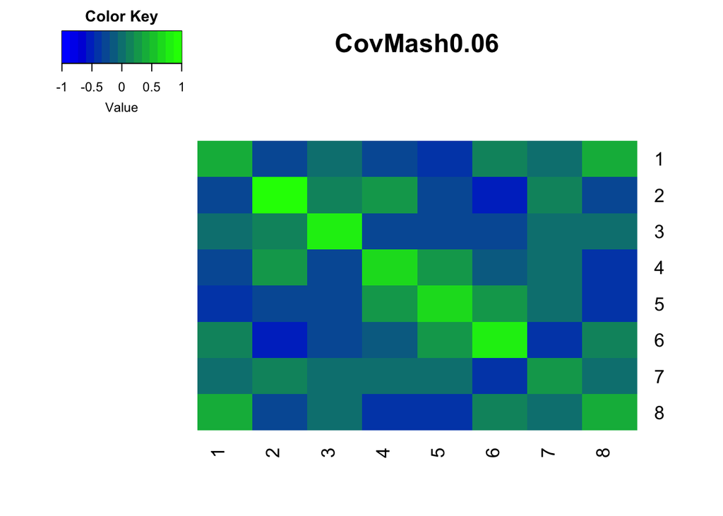

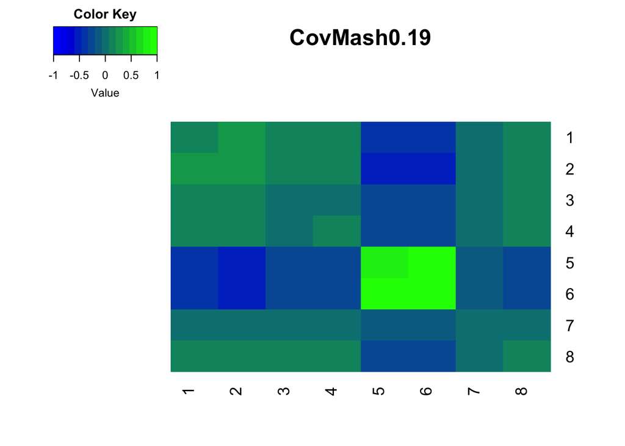

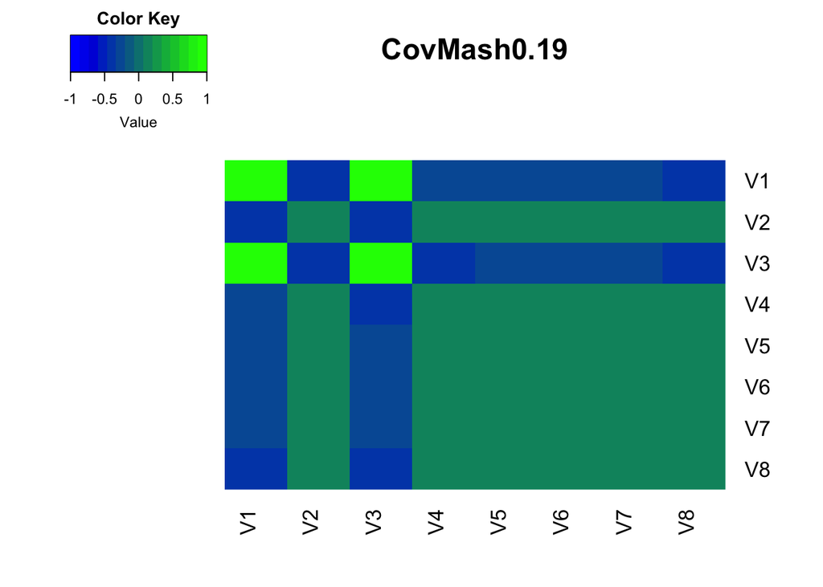

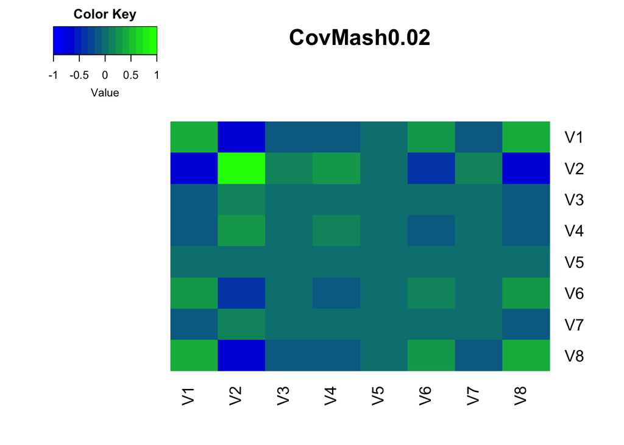

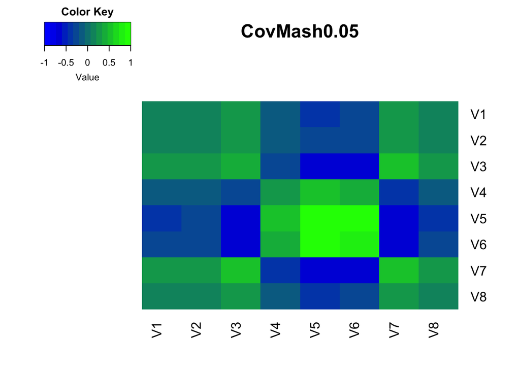

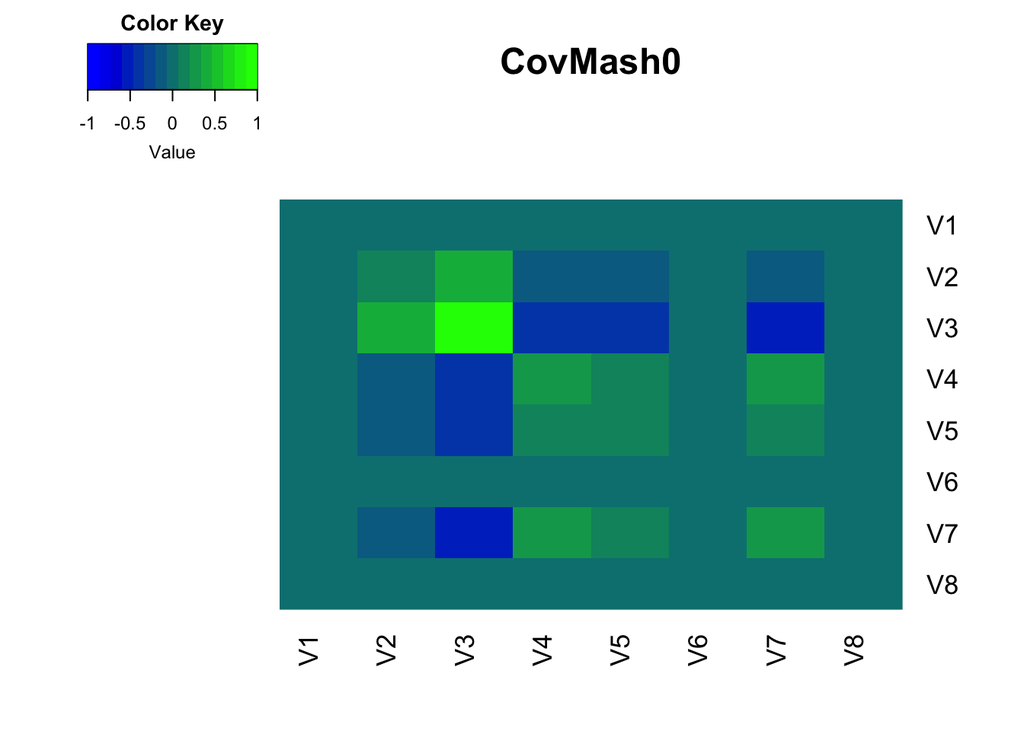

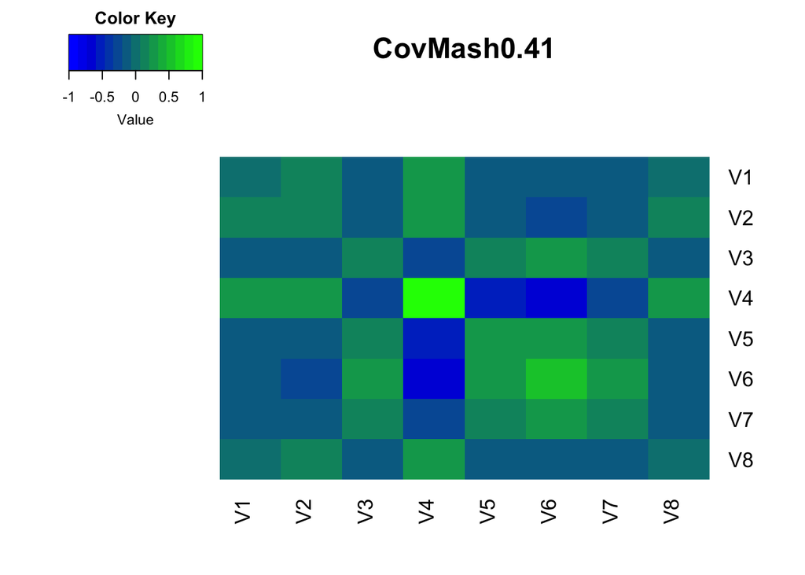

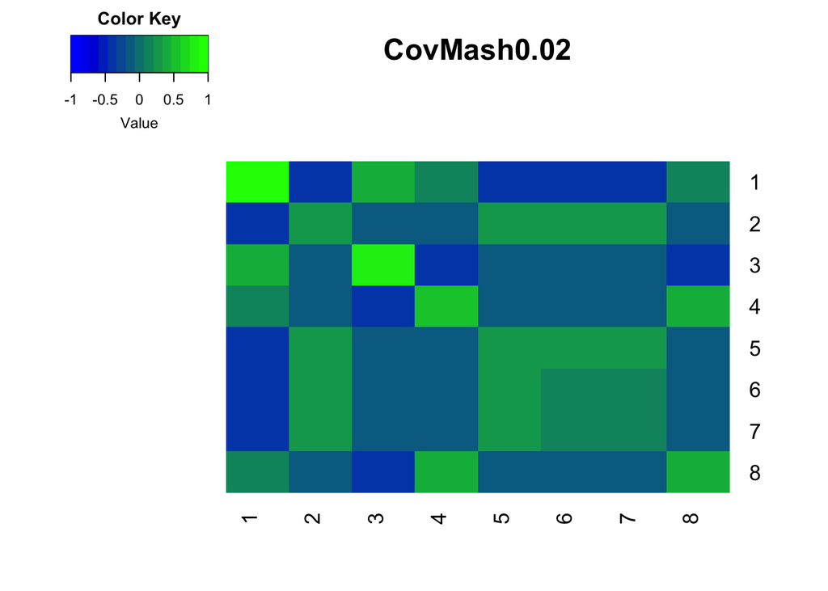

```r
covmash=readRDS("covmatsparseoldmash.rds")
coved=readRDS("covmatsparseL.rds")
library('gplots')
library('colorRamps')

for(i in 2:9){
  x=covmash[[i]]
  heatmap.2(x/max(diag(x)),Rowv = NULL,Colv = NULL,dendrogram = "none",col=blue2green,density.info = "none",trace="none",main=paste0("CovMash",round(colSums(pi.mat.old.mash)[i],2)))}
```

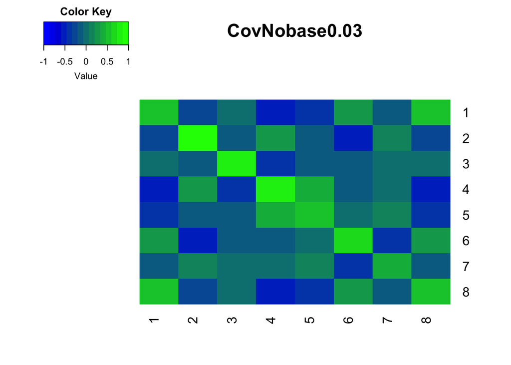

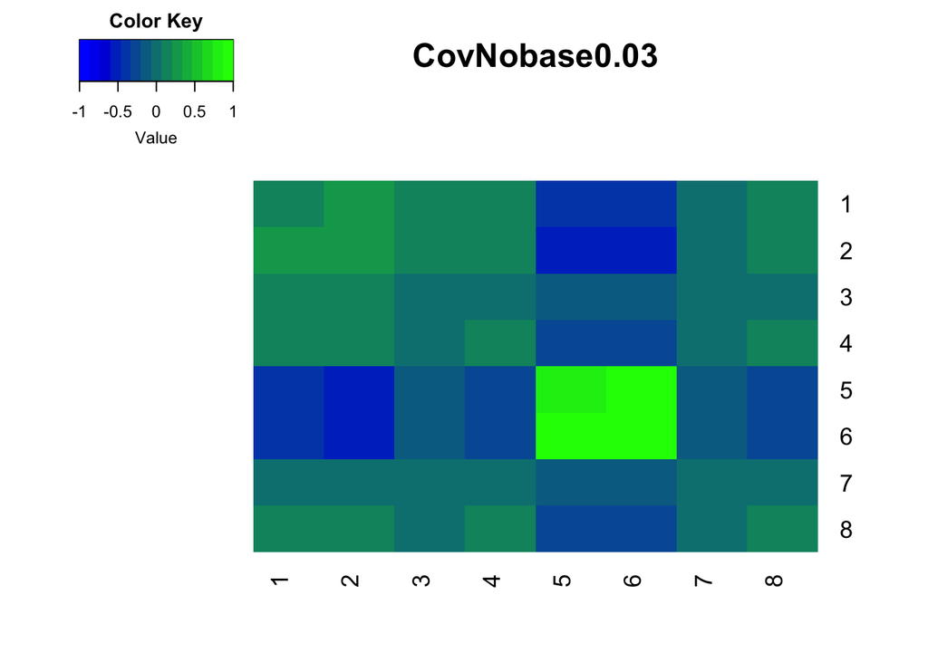

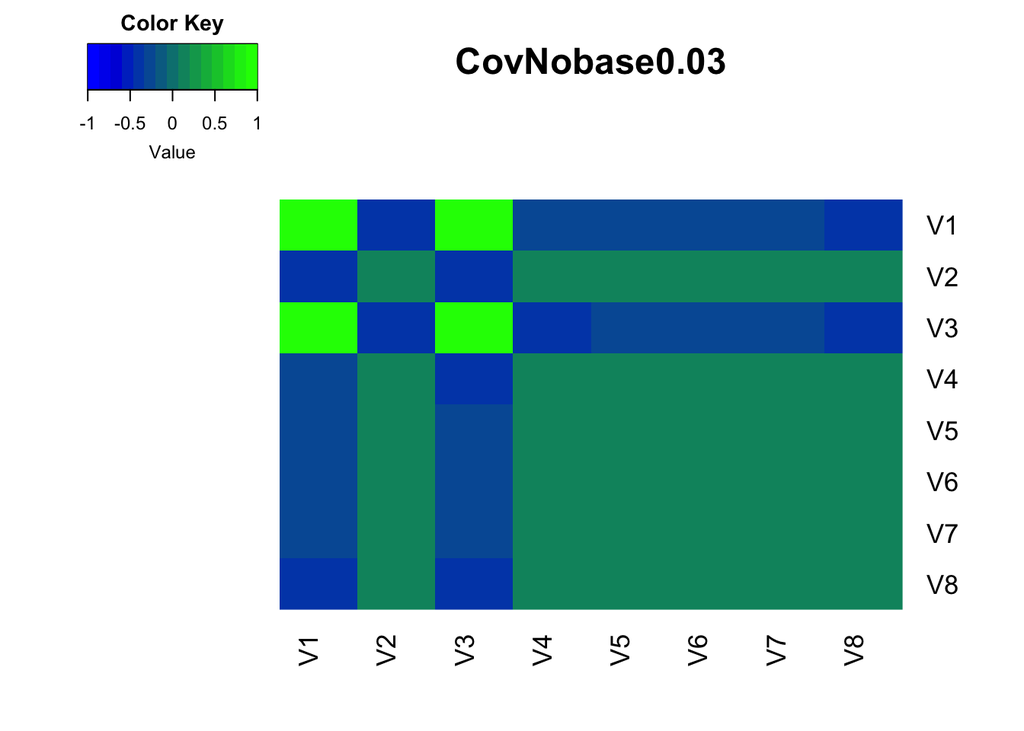

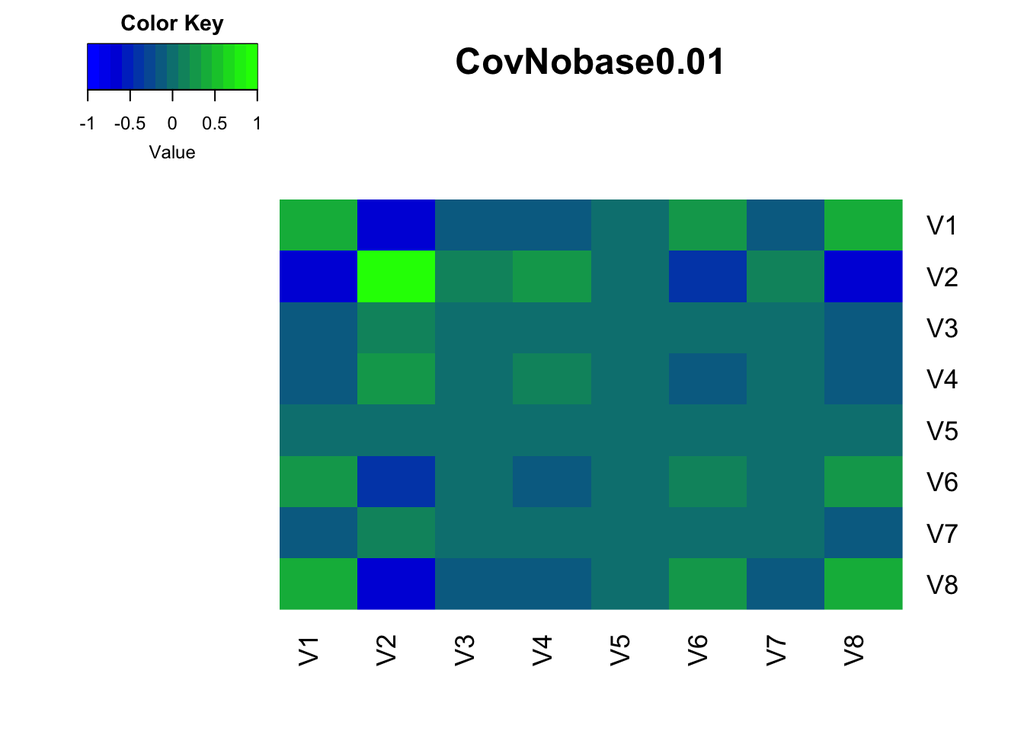

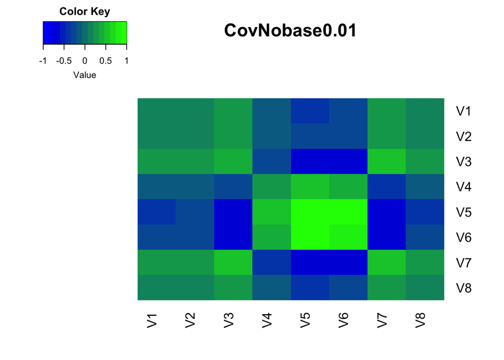

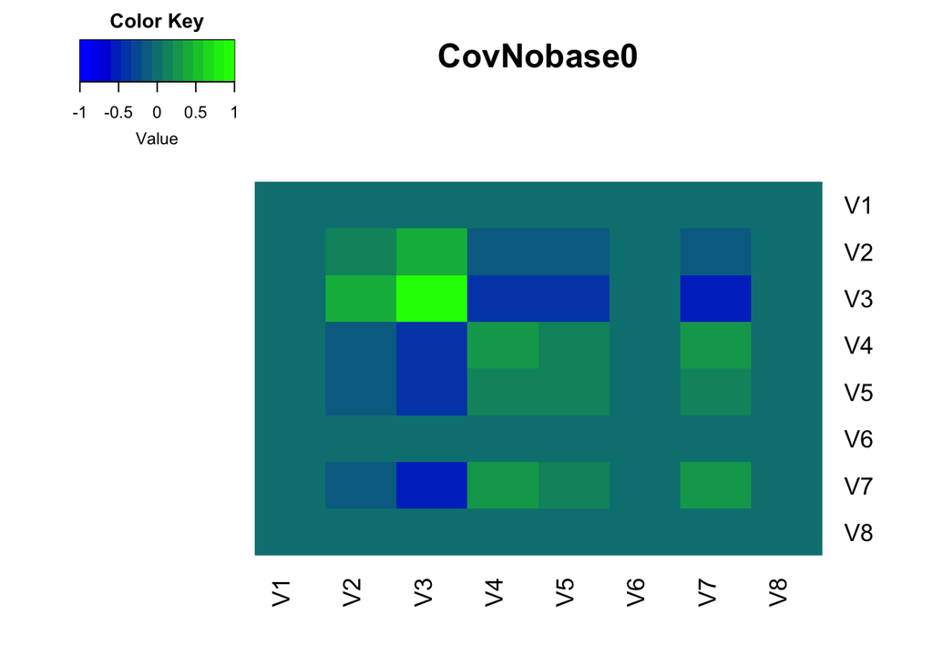

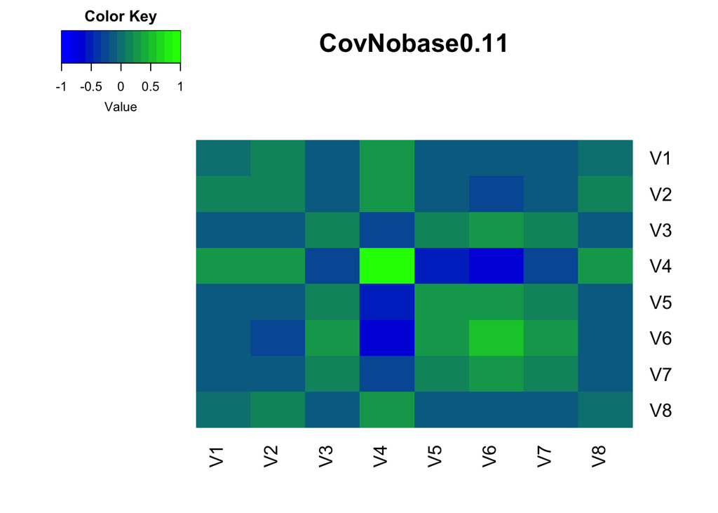

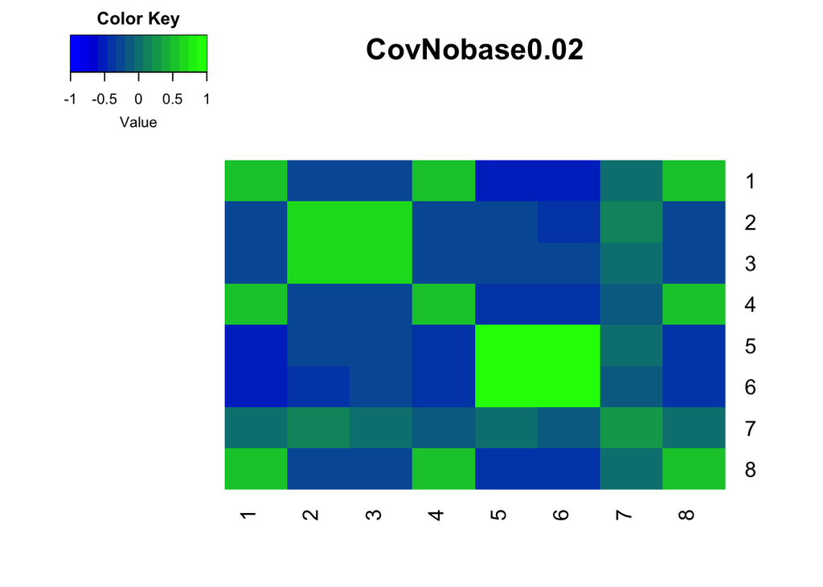

```r
for(i in 2:9){
  x=coved[[i]]
  heatmap.2(x/max(diag(x)),Rowv = NULL,Colv = NULL,dendrogram = "none",col=blue2green,density.info = "none",trace="none",main=paste0("CovNobase",round(colSums(pi.mat.nobase)[i],2)))}
```

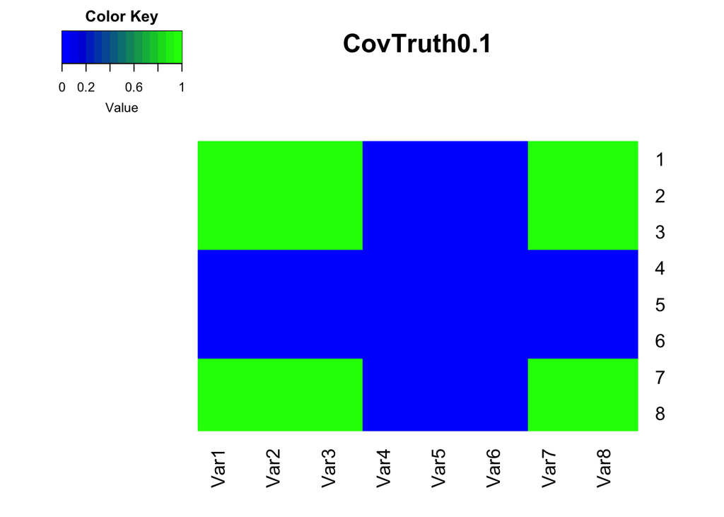

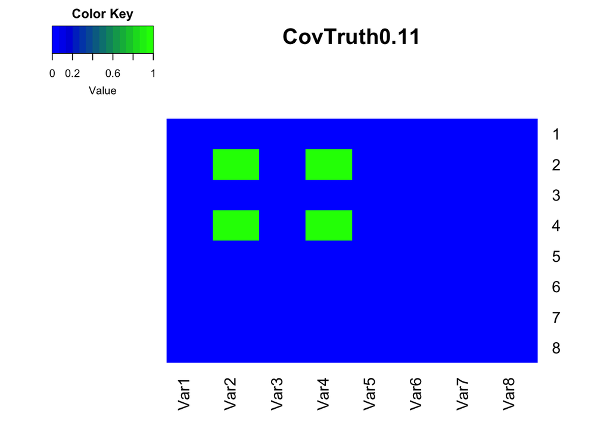

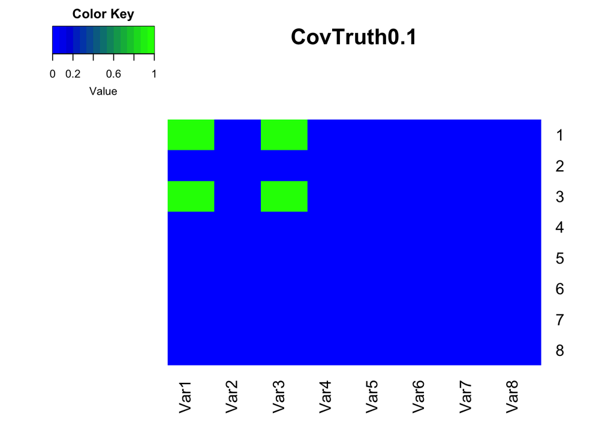

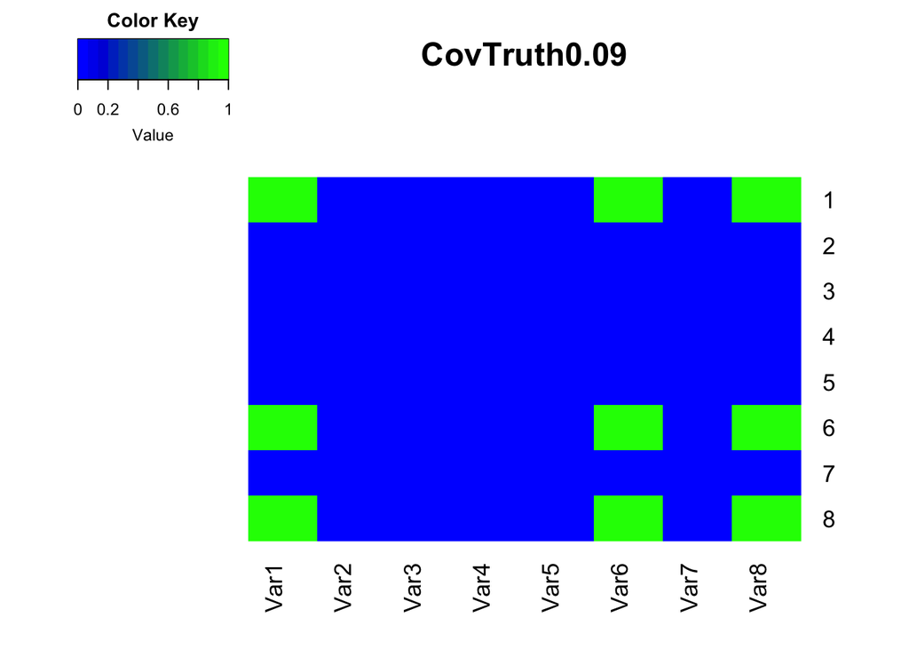

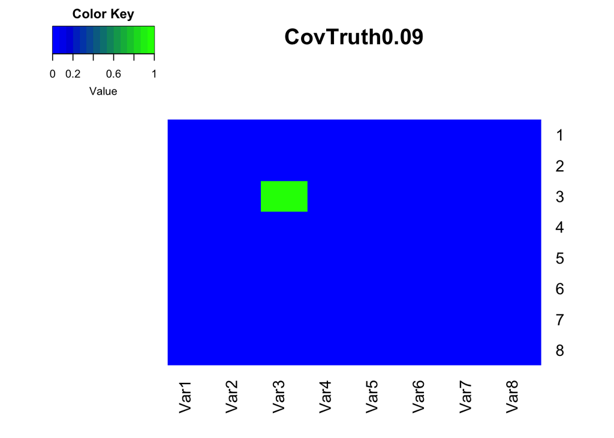

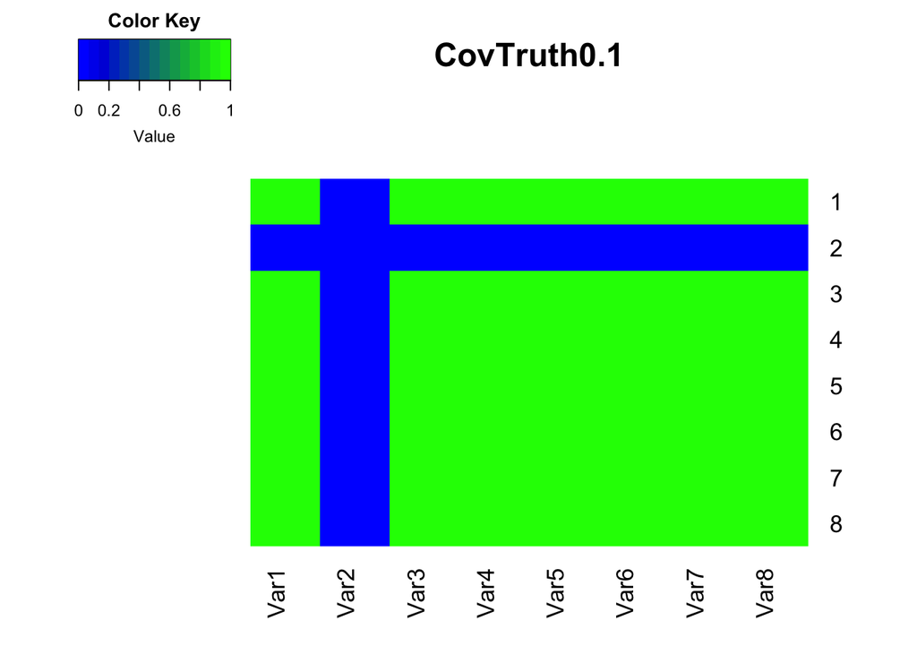

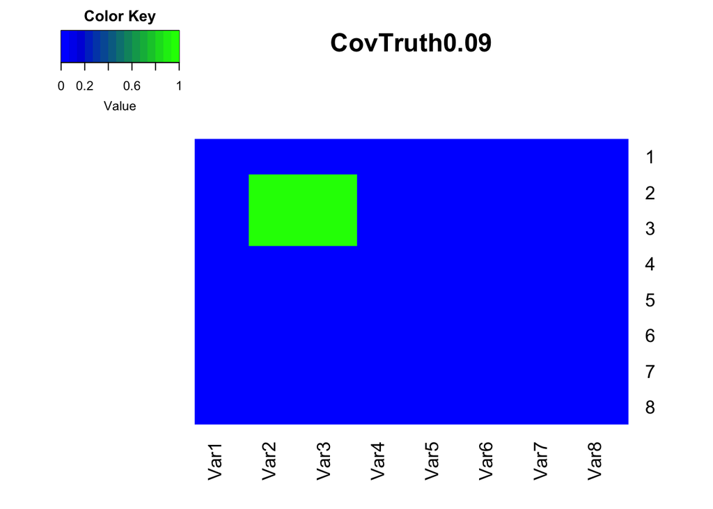

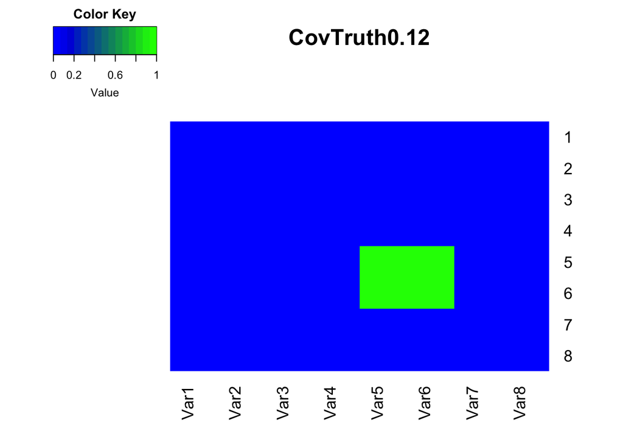

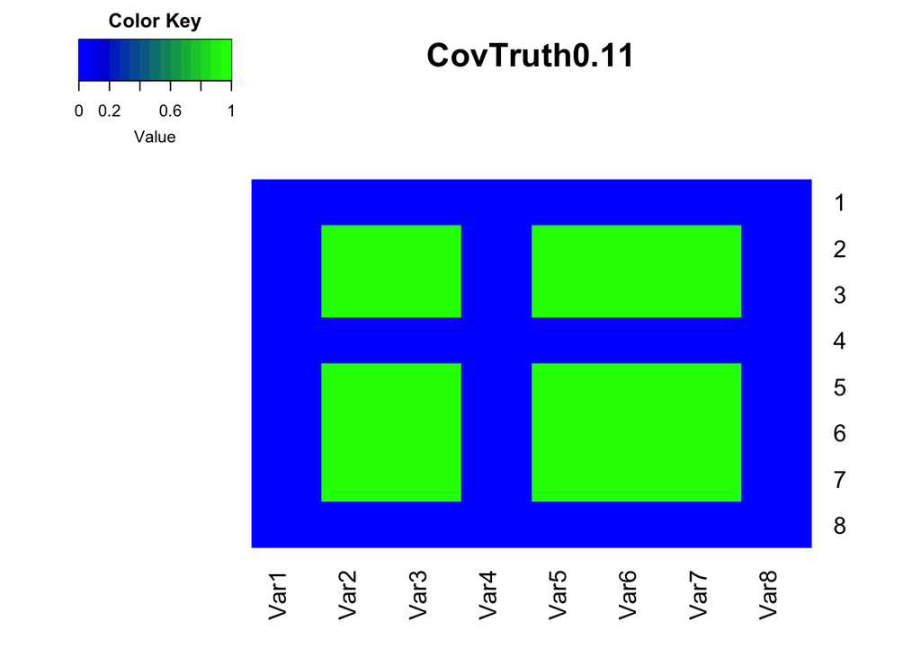

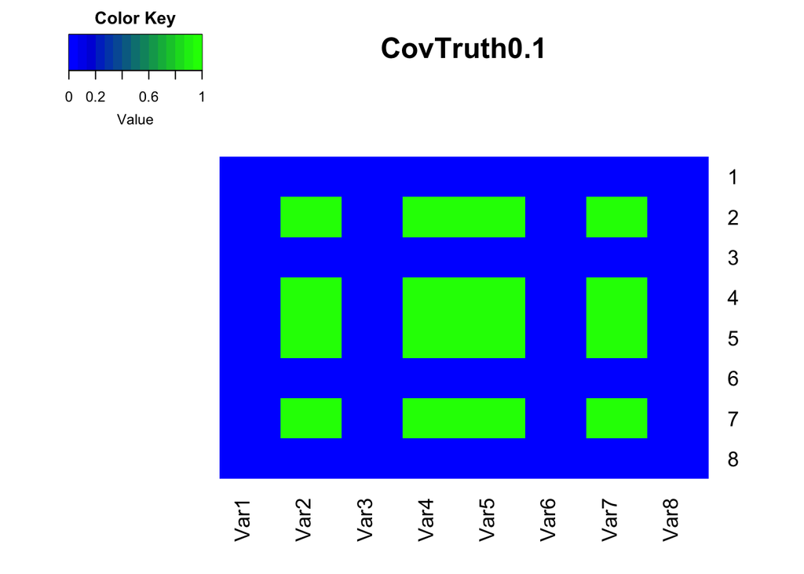

```r
truepis=table(c$components)/sum(table(c$components))
for(i in 1:length(c$covmat)){
    x=c$covmat[[i]]
    truepi=round(truepis[i],2)
  heatmap.2(x/max(diag(x)),Rowv = NULL,Colv = NULL,dendrogram = "none",col=blue2green,density.info = "none",trace="none",main=paste0("CovTruth",truepi))}
```